# Exploring the Data

Summary statistics, missing values, and visuals

Shukria Alavi

2026-10-11

This file sits between `01_join_and_clean.Rmd` and `02_analysis.Rmd`. It describes the data before any model is fitted: what the variables look like, what is missing, and what the patterns are.

Every visual below states the question it is there to answer. A chart that does not answer a question does not belong in the paper.

```r
# patchwork is only used for the final side-by-side figure.
# install.packages("patchwork")   # run once in the console if needed
library(tidyverse)
library(patchwork)

data <- read_csv("data_clean/analysis_data.csv", show_col_types = FALSE)
dim(data)
```

```
## [1] 89 13
```

# Part 1: Where the data comes from

| Source | What I take from it | Coverage |
| --- | --- | --- |
| World Bank **Global Findex 2025** | Internet use by women and by men. Gallup surveyed adults aged 15+ in each country between May and December 2024, same question everywhere. | My independent variable |
| World Bank **World Development Indicators** | GDP per capita (PPP), female labour force participation, female secondary enrollment, overall internet use, urban share. Most recent value 2021–2024. | My three outcomes plus two controls |
| UNDP **Human Development Report 2025** | Gender Inequality Index, 2023. Higher means more unequal. | An extra control |

All three were downloaded and reduced by `00_download_sources.R` and joined on ISO-3 country code in `01_join_and_clean.Rmd`. Nothing was edited by hand at any point.

# Part 2: Summary statistics

```r
summary_table <- data %>%
  select(internet_women, internet_men, gap_diff, gap_ratio,
         gdp_pc_ppp, flfp, sec_enroll_fem_gross,
         internet_total, urban_pct, gender_inequality_index) %>%
  pivot_longer(everything(), names_to = "variable", values_to = "value") %>%
  group_by(variable) %>%
  summarise(
    n       = sum(!is.na(value)),
    missing = sum(is.na(value)),
    mean    = round(mean(value,   na.rm = TRUE), 2),
    sd      = round(sd(value,     na.rm = TRUE), 2),
    min     = round(min(value,    na.rm = TRUE), 2),
    median  = round(median(value, na.rm = TRUE), 2),
    max     = round(max(value,    na.rm = TRUE), 2),
    .groups = "drop"
  ) %>%
  mutate(variable = factor(variable, levels = c(
    "internet_women", "internet_men", "gap_diff", "gap_ratio",
    "gdp_pc_ppp", "flfp", "sec_enroll_fem_gross",
    "internet_total", "urban_pct", "gender_inequality_index"))) %>%
  arrange(variable)

knitr::kable(summary_table)
```

| variable | n | missing | mean | sd | min | median | max |
| --- | --- | --- | --- | --- | --- | --- | --- |
| internet_women | 89 | 0 | 60.47 | 26.13 | 7.17 | 67.76 | 93.70 |
| internet_men | 89 | 0 | 66.53 | 21.26 | 14.91 | 71.86 | 96.68 |
| gap_diff | 89 | 0 | 6.06 | 8.51 | -8.04 | 4.79 | 43.61 |
| gap_ratio | 89 | 0 | 0.87 | 0.18 | 0.24 | 0.93 | 1.10 |
| gdp_pc_ppp | 88 | 1 | 12043.02 | 8638.83 | 1500.71 | 10427.24 | 36154.49 |
| flfp | 89 | 0 | 49.82 | 16.85 | 11.00 | 51.72 | 82.92 |
| sec_enroll_fem_gross | 74 | 15 | 78.32 | 24.47 | 19.44 | 86.38 | 116.87 |
| internet_total | 89 | 0 | 63.42 | 24.56 | 8.95 | 68.72 | 98.02 |
| urban_pct | 89 | 0 | 55.88 | 19.50 | 17.27 | 58.55 | 92.95 |
| gender_inequality_index | 87 | 2 | 0.42 | 0.15 | 0.11 | 0.44 | 0.68 |

# Part 3: What is missing

```r
data %>%
  summarise(across(everything(), ~ sum(is.na(.)))) %>%
  pivot_longer(everything(), names_to = "variable", values_to = "missing") %>%
  filter(missing > 0) %>%
  arrange(desc(missing))
```

```
## # A tibble: 4 × 2
##   variable                missing
##   <chr>                     <int>
## 1 sec_enroll_fem_gross         15
## 2 gender_inequality_index       2
## 3 gdp_pc_ppp                    1
## 4 log_gdp                       1
```

Which countries, specifically:

```r
data %>%
  select(country, gdp_pc_ppp, sec_enroll_fem_gross, gender_inequality_index) %>%
  pivot_longer(-country, names_to = "variable", values_to = "value") %>%
  filter(is.na(value)) %>%
  group_by(variable) %>%
  summarise(n_missing = n(),
            countries = paste(sort(country), collapse = ", "),
            .groups = "drop")
```

```
## # A tibble: 3 × 3
##   variable                n_missing countries
##   <chr>                       <int> <chr>
## 1 gdp_pc_ppp                      1 Venezuela, RB
## 2 gender_inequality_index         2 Ukraine, West Bank and Gaza
## 3 sec_enroll_fem_gross           15 China, Congo, Rep., Eswatini, Ethiopia, Gab…
```

Three things to say about this:

- Female secondary enrollment is my weakest variable. 15 of 89 countries have no figure, which drops my enrollment models to n = 74.
- The missingness is not random. The countries without an enrollment figure are mostly lower-income, which means the enrollment results describe a slightly better-off subset of my sample.
- I did not impute anything. Every model simply uses the countries that have the variables it needs, and I report the n for each one.

# Part 4: The visuals

I add world region here so I can look at the gap geographically. Region is not in the analysis file, so I attach it from the World Bank’s classification.

```r
region_lookup <- c(
  # Europe & Central Asia
  ALB="Europe & Central Asia", ARM="Europe & Central Asia",
  AZE="Europe & Central Asia", BIH="Europe & Central Asia",
  GEO="Europe & Central Asia", KAZ="Europe & Central Asia",
  KGZ="Europe & Central Asia", MDA="Europe & Central Asia",
  MNE="Europe & Central Asia", MKD="Europe & Central Asia",
  SRB="Europe & Central Asia", TJK="Europe & Central Asia",
  TUR="Europe & Central Asia", UKR="Europe & Central Asia",
  UZB="Europe & Central Asia",
  # Middle East & North Africa
  DZA="Middle East & North Africa", EGY="Middle East & North Africa",
  IRN="Middle East & North Africa", IRQ="Middle East & North Africa",
  JOR="Middle East & North Africa", LBN="Middle East & North Africa",
  LBY="Middle East & North Africa", MAR="Middle East & North Africa",
  TUN="Middle East & North Africa", PSE="Middle East & North Africa",
  # Latin America & Caribbean
  ARG="Latin America & Caribbean", BLZ="Latin America & Caribbean",
  BOL="Latin America & Caribbean", BRA="Latin America & Caribbean",
  COL="Latin America & Caribbean", DOM="Latin America & Caribbean",
  ECU="Latin America & Caribbean", SLV="Latin America & Caribbean",
  GTM="Latin America & Caribbean", HND="Latin America & Caribbean",
  MEX="Latin America & Caribbean", NIC="Latin America & Caribbean",
  PRY="Latin America & Caribbean", PER="Latin America & Caribbean",
  VEN="Latin America & Caribbean",
  # South Asia
  BGD="South Asia", IND="South Asia", LKA="South Asia",
  NPL="South Asia", PAK="South Asia",
  # East Asia & Pacific
  KHM="East Asia & Pacific", CHN="East Asia & Pacific",
  IDN="East Asia & Pacific", LAO="East Asia & Pacific",
  MYS="East Asia & Pacific", MNG="East Asia & Pacific",
  PHL="East Asia & Pacific", THA="East Asia & Pacific",
  VNM="East Asia & Pacific",
  # Sub-Saharan Africa
  BEN="Sub-Saharan Africa", BWA="Sub-Saharan Africa",
  BFA="Sub-Saharan Africa", CMR="Sub-Saharan Africa",
  TCD="Sub-Saharan Africa", COM="Sub-Saharan Africa",
  COD="Sub-Saharan Africa", COG="Sub-Saharan Africa",
  CIV="Sub-Saharan Africa", SWZ="Sub-Saharan Africa",
  ETH="Sub-Saharan Africa", GAB="Sub-Saharan Africa",
  GMB="Sub-Saharan Africa", GHA="Sub-Saharan Africa",
  GIN="Sub-Saharan Africa", KEN="Sub-Saharan Africa",
  LSO="Sub-Saharan Africa", LBR="Sub-Saharan Africa",
  MDG="Sub-Saharan Africa", MWI="Sub-Saharan Africa",
  MLI="Sub-Saharan Africa", MRT="Sub-Saharan Africa",
  MUS="Sub-Saharan Africa", MOZ="Sub-Saharan Africa",
  NAM="Sub-Saharan Africa", NER="Sub-Saharan Africa",
  NGA="Sub-Saharan Africa", SEN="Sub-Saharan Africa",
  SLE="Sub-Saharan Africa", ZAF="Sub-Saharan Africa",
  TZA="Sub-Saharan Africa", TGO="Sub-Saharan Africa",
  UGA="Sub-Saharan Africa", ZMB="Sub-Saharan Africa",
  ZWE="Sub-Saharan Africa"
)

data <- data %>% mutate(region = unname(region_lookup[country_code]))

# every country should have a region
sum(is.na(data$region))
```

```
## [1] 0
```

```r
count(data, region)
```

```
## # A tibble: 6 × 2
##   region                         n
##   <chr>                      <int>
## 1 East Asia & Pacific            9
## 2 Europe & Central Asia         15
## 3 Latin America & Caribbean     15
## 4 Middle East & North Africa    10
## 5 South Asia                     5
## 6 Sub-Saharan Africa            35
```

## Visual 1: How big is the gap?

**The question:** how wide is the internet gender gap, and how much do countries differ?

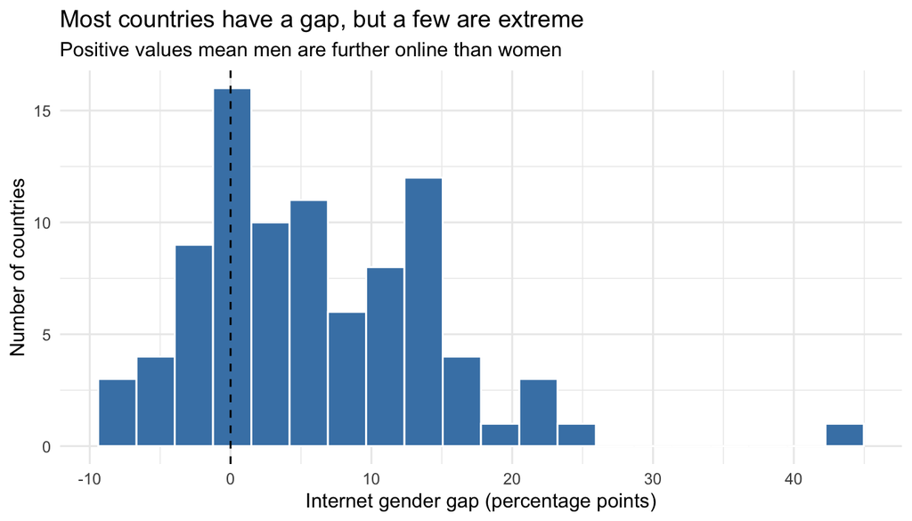

```r
fig1 <- ggplot(data, aes(x = gap_diff)) +
  geom_histogram(bins = 20, fill = "steelblue", colour = "white") +
  geom_vline(xintercept = 0, linetype = "dashed") +
  labs(title = "Most countries have a gap, but a few are extreme",
       subtitle = "Positive values mean men are further online than women",
       x = "Internet gender gap (percentage points)",
       y = "Number of countries") +
  theme_minimal()

fig1
```

## Visual 2: Which countries are at the extremes?

**The question:** where is the gap widest, and where are women actually ahead?

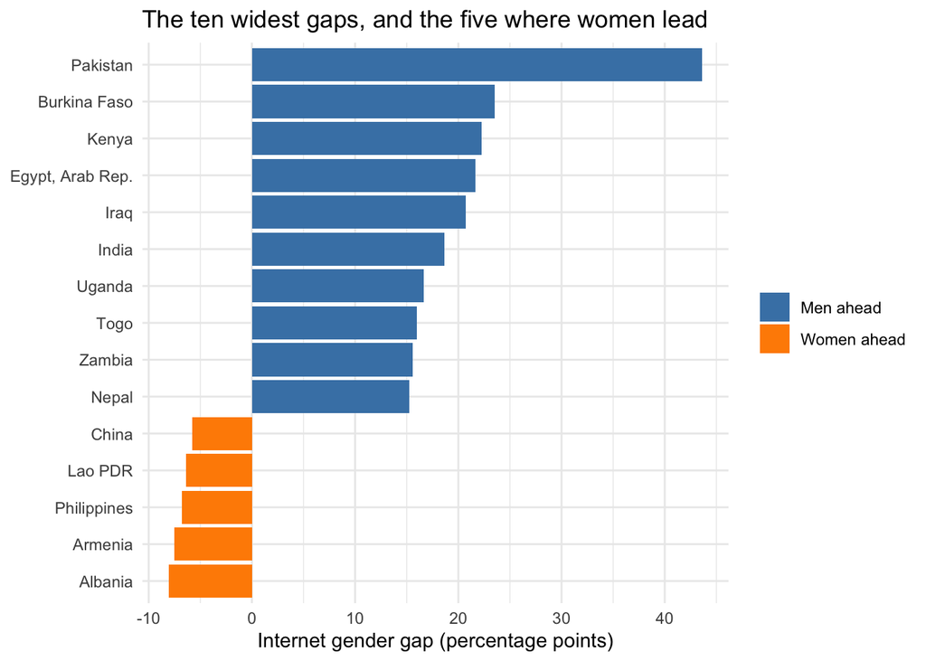

```r
extremes <- bind_rows(
  data %>% slice_max(gap_diff, n = 10),
  data %>% slice_min(gap_diff, n = 5)
) %>%
  mutate(side = if_else(gap_diff > 0, "Men ahead", "Women ahead"))

fig2 <- ggplot(extremes, aes(x = reorder(country, gap_diff), y = gap_diff,
                             fill = side)) +
  geom_col() +
  coord_flip() +
  scale_fill_manual(values = c("Men ahead" = "steelblue",
                               "Women ahead" = "darkorange")) +
  labs(title = "The ten widest gaps, and the five where women lead",
       x = NULL,
       y = "Internet gender gap (percentage points)",
       fill = NULL) +
  theme_minimal()

fig2
```

Pakistan is an enormous outlier at 43.6 points.

## Visual 3: Is the gap worse where fewer people are online?

**The question:** does the gap shrink as a country gets more connected overall? This matters because it is the reason I control for total internet use later.

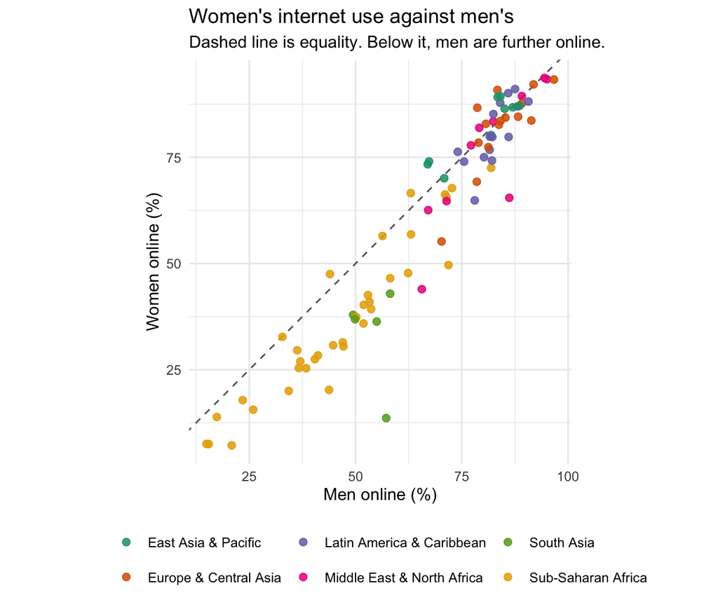

```r
fig3 <- ggplot(data, aes(x = internet_men, y = internet_women)) +
  geom_abline(slope = 1, intercept = 0, linetype = "dashed",
              colour = "grey40") +
  geom_point(aes(colour = region), alpha = 0.85, size = 2) +
  # Dark2 is colour-blind friendly, unlike ggplot's default palette
  scale_colour_brewer(palette = "Dark2") +
  labs(title = "Women's internet use against men's",
       subtitle = "Dashed line is equality. Below it, men are further online.",
       x = "Men online (%)", y = "Women online (%)", colour = NULL) +
  coord_equal() +
  theme_minimal() +
  theme(legend.position = "bottom")

fig3
```

## Visual 4: Where is the gap concentrated?

**The question:** is the gap a regional phenomenon or spread evenly?

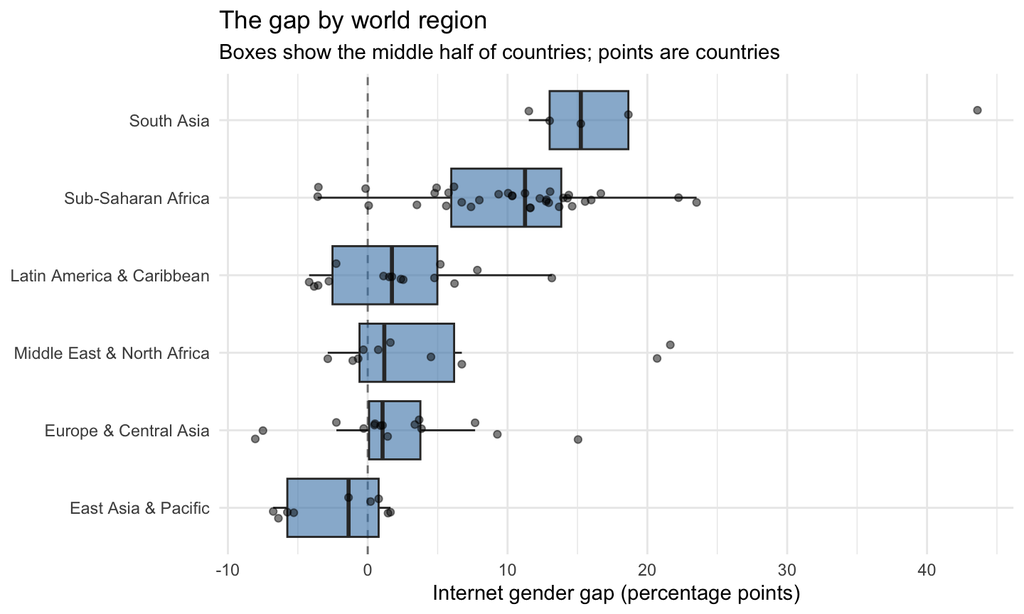

```r
fig4 <- data %>%
  mutate(region = fct_reorder(region, gap_diff, .fun = median)) %>%
  ggplot(aes(x = region, y = gap_diff)) +
  geom_hline(yintercept = 0, linetype = "dashed", colour = "grey50") +
  geom_boxplot(fill = "steelblue", alpha = 0.6, outlier.shape = NA) +
  geom_jitter(width = 0.15, alpha = 0.5, size = 1.5) +
  coord_flip() +
  labs(title = "The gap by world region",
       subtitle = "Boxes show the middle half of countries; points are countries",
       x = NULL, y = "Internet gender gap (percentage points)") +
  theme_minimal()

fig4
```

## Visual 5: The gap against each outcome

**The question:** before any controls, does the gap look related to my three outcomes?

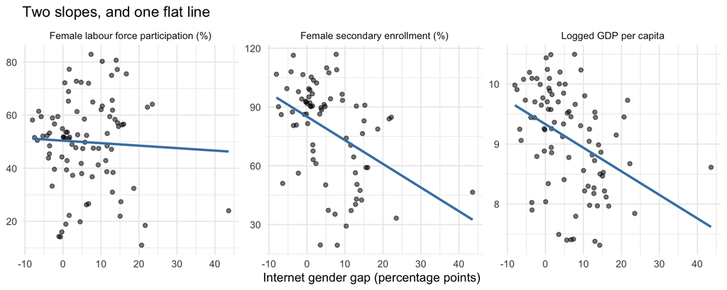

```r
outcome_long <- data %>%
  select(country, gap_diff, log_gdp, flfp, sec_enroll_fem_gross) %>%
  pivot_longer(c(log_gdp, flfp, sec_enroll_fem_gross),
               names_to = "outcome", values_to = "value") %>%
  mutate(outcome = recode(outcome,
    log_gdp              = "Logged GDP per capita",
    flfp                 = "Female labour force participation (%)",
    sec_enroll_fem_gross = "Female secondary enrollment (%)"))

fig5 <- ggplot(outcome_long, aes(x = gap_diff, y = value)) +
  geom_point(alpha = 0.55) +
  geom_smooth(method = "lm", se = FALSE, colour = "steelblue") +
  facet_wrap(~ outcome, scales = "free_y") +
  labs(title = "Two slopes, and one flat line",
       x = "Internet gender gap (percentage points)", y = NULL) +
  theme_minimal()

fig5
```

GDP and enrollment slope down. Female labour force participation is flat.

## Visual 6: The final figure

**The question:** what does the relationship between the gap and female labour force participation look like once I hold overall internet use and urbanisation constant?

A plain scatter of the two shows nothing. The added variable plot removes the part of each variable that the controls already explain, and shows what is left — which is the relationship the regression actually estimates.

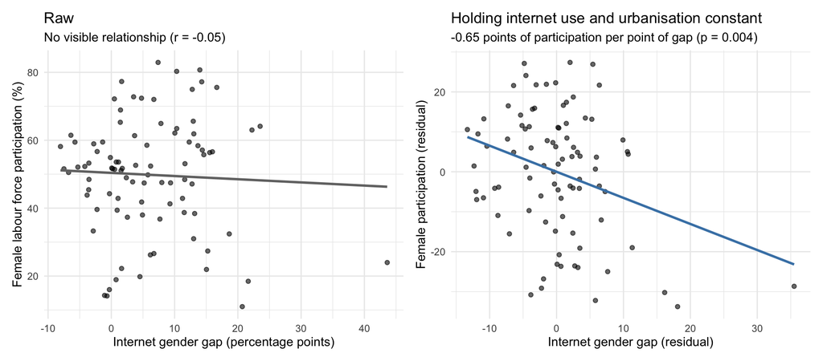

```r
# none of these four columns has a missing value, so the residuals line up
# with all 89 rows of the data frame
plot_data <- data
plot_data$flfp_resid <- residuals(lm(flfp ~ internet_total + urban_pct,
                                     data = data))
plot_data$gap_resid  <- residuals(lm(gap_diff ~ internet_total + urban_pct,
                                     data = data))

panel_raw <- ggplot(plot_data, aes(gap_diff, flfp)) +
  geom_point(alpha = 0.6) +
  geom_smooth(method = "lm", se = FALSE, colour = "grey45") +
  labs(title = "Raw",
       subtitle = "No visible relationship (r = -0.05)",
       x = "Internet gender gap (percentage points)",
       y = "Female labour force participation (%)") +
  theme_minimal()

panel_adj <- ggplot(plot_data, aes(gap_resid, flfp_resid)) +
  geom_point(alpha = 0.6) +
  geom_smooth(method = "lm", se = FALSE, colour = "steelblue") +
  labs(title = "Holding internet use and urbanisation constant",
       subtitle = "-0.65 points of participation per point of gap (p = 0.004)",
       x = "Internet gender gap (residual)",
       y = "Female participation (residual)") +
  theme_minimal()

fig6 <- panel_raw + panel_adj
fig6
```

# Part 5: Save the figures

```r
if (!dir.exists("figures")) dir.create("figures")

ggsave("figures/fig1_gap_distribution.png", fig1, width = 7,  height = 4,   dpi = 300)
ggsave("figures/fig2_extremes.png",         fig2, width = 7,  height = 5,   dpi = 300)
ggsave("figures/fig3_women_vs_men.png",     fig3, width = 6.5,height = 5.5, dpi = 300)
ggsave("figures/fig4_by_region.png",        fig4, width = 7.5,height = 4.5, dpi = 300)
ggsave("figures/fig5_gap_vs_outcomes.png",  fig5, width = 9,  height = 3.6, dpi = 300)
ggsave("figures/fig6_final.png",            fig6, width = 10, height = 4.4, dpi = 300)

list.files("figures")
```

```
## [1] "fig1_gap_distribution.png" "fig2_extremes.png"
## [3] "fig3_women_vs_men.png"     "fig4_by_region.png"
## [5] "fig5_gap_vs_outcomes.png"  "fig6_final.png"
```

Also save the summary table, so the paper and the code never disagree.

```r
if (!dir.exists("results")) dir.create("results")
write_csv(summary_table, "results/summary_statistics.csv")
```